# Wrangle data Process

```python
#import neccessary libaries
import pandas as pd
import numpy as np
import json
import requests
import re
import matplotlib.pyplot as plt
%matplotlib inline
import seaborn as sb
```

**GATHERING DATA**

Here I will be gathering the weratedog data to be used for the data wrangling project. This will include loading the twitter archive enhanced csv file as provided, the image predictions.tsv file from the provided url using the request library and the tweet_json.text file as provided.

```python
#Reading the First file into the dataframe
data_csv = pd.read_csv('twitter-archive-enhanced.csv', encoding='utf-8')
```

```python
#loading dataset from json.text
data_json= pd.read_json('tweet-json.txt', lines=True)
```

```python
#using request library to download a file
url ='https://d17h27t6h515a5.cloudfront.net/topher/2017/August/599fd2ad_image-predictions/image-predictions.tsv'
response =requests.get(url)
with open (url.split('/')[-1], mode='wb') as f:
    f.write(response.content)
#loading dataset from the tsv file
data_tsv= pd.read_csv('tweet_tsv', sep='\t')
```

**ASSESSING DATA**

I have read the required data into the dataframe and the next step is assess the data for quality issues. I will be using the visual and programmatic assessment in carrying out this task

*Data1: Twitter Archive Enhanced File*

Tidiness Issue

1. The doggo, fuffer, pupper, and puppo observations should be changed from wide to long.

Dirty data

1. The expanded urls have 137 duplicated values
2. Invalid tweet_id datatype(categorized as int instead of string)
3. erroneous values in some rows under rating_denominator which is meant to be a constant value of 10
4. The datatype of retweeted_status_timestamp is wrong(object instead of datetime
5. wrong dtype for the stages of the dogs (doggo fuffer pupper and puppo)- object instead of categorydtype
6. Missing Data for in_reply_to_status_id, in_reply_to_user_id, retweeted_status_id, retweeted_status_user_id, retweeted_status_timestamp and expanded_urls
7. The tweet_link should be removed as they are can be traced using the tweet_id.
8. The source column contains unneccessary information.
9. The None observation under dog stages should be replaced with NAN

*Data2 : Tweet Json File*

Tidiness Issue

1. The dataframe should not be isolated

Dirty data

1. The primary key (tweet_id) is named wrongly as id in the dataframe.
2. The data is incomplete..it has 2354 rows as compared to 2356 rows in the twitter archive enhanced file

*Data3 : Image prediction tsv file*

Tidiness Issue

Dirty Data

1. The image prediction data is imcomplete, it has 2075 observations

```python
#assess the twitter archive enhanced data
data_csv.info()
```

```
<class 'pandas.core.frame.DataFrame'>
RangeIndex: 2356 entries, 0 to 2355
Data columns (total 17 columns):
tweet_id                      2356 non-null int64
in_reply_to_status_id         78 non-null float64
in_reply_to_user_id           78 non-null float64
timestamp                     2356 non-null object
source                        2356 non-null object
text                          2356 non-null object
retweeted_status_id           181 non-null float64
retweeted_status_user_id      181 non-null float64
retweeted_status_timestamp    181 non-null object
expanded_urls                 2297 non-null object
rating_numerator              2356 non-null int64
rating_denominator            2356 non-null int64
name                          2356 non-null object
doggo                         2356 non-null object
floofer                       2356 non-null object
pupper                        2356 non-null object
puppo                         2356 non-null object
dtypes: float64(4), int64(3), object(10)
memory usage: 313.0+ KB
```

```python
data_csv.duplicated().sum()
```

[output not shown]

```python
data_csv.rating_numerator.describe()
```

```
count    2356.000000
mean       13.126486
std        45.876648
min         0.000000
25%        10.000000
50%        11.000000
75%        12.000000
max      1776.000000
Name: rating_numerator, dtype: float64
```

```python
data_csv.rating_denominator.describe()
```

```
count    2356.000000
mean       10.455433
std         6.745237
min         0.000000
25%        10.000000
50%        10.000000
75%        10.000000
max       170.000000
Name: rating_denominator, dtype: float64
```

```python
data_csv.doggo.unique()
```

```
array(['None', 'doggo'], dtype=object)
```

```python
data_csv.floofer.unique()
```

```
array(['None', 'floofer'], dtype=object)
```

```python
data_csv.expanded_urls.nunique()
```

```
2218
```

```python
data_csv.source
```

```
0       <a href="http://twitter.com/download/iphone" r...
1       <a href="http://twitter.com/download/iphone" r...
2       <a href="http://twitter.com/download/iphone" r...
3       <a href="http://twitter.com/download/iphone" r...
4       <a href="http://twitter.com/download/iphone" r...
5       <a href="http://twitter.com/download/iphone" r...
6       <a href="http://twitter.com/download/iphone" r...
7       <a href="http://twitter.com/download/iphone" r...
8       <a href="http://twitter.com/download/iphone" r...
9       <a href="http://twitter.com/download/iphone" r...
10      <a href="http://twitter.com/download/iphone" r...
11      <a href="http://twitter.com/download/iphone" r...
12      <a href="http://twitter.com/download/iphone" r...
13      <a href="http://twitter.com/download/iphone" r...
14      <a href="http://twitter.com/download/iphone" r...
```

[output cut: 47 more lines]

```python
#assess the tweet_json file
print(data_json)
#Extract the needed columns from the dataframe
data_json = data_json[['id','retweet_count', 'favorite_count' ]]
```

```
      contributors  coordinates          created_at display_text_range  \
0              NaN          NaN 2017-08-01 16:23:56            [0, 85]
1              NaN          NaN 2017-08-01 00:17:27           [0, 138]
2              NaN          NaN 2017-07-31 00:18:03           [0, 121]
3              NaN          NaN 2017-07-30 15:58:51            [0, 79]
4              NaN          NaN 2017-07-29 16:00:24           [0, 138]
5              NaN          NaN 2017-07-29 00:08:17           [0, 138]
6              NaN          NaN 2017-07-28 16:27:12           [0, 140]
7              NaN          NaN 2017-07-28 00:22:40           [0, 118]
8              NaN          NaN 2017-07-27 16:25:51           [0, 122]
9              NaN          NaN 2017-07-26 15:59:51           [0, 133]
10             NaN          NaN 2017-07-26 00:31:25           [0, 130]
11             NaN          NaN 2017-07-25 16:11:53           [0, 107]
12             NaN          NaN 2017-07-25 01:55:32           [0, 106]
13             NaN          NaN 2017-07-25 00:10:02            [0, 91]
```

[output cut: 553 more lines]

```python
data_json.info()
```

```
<class 'pandas.core.frame.DataFrame'>
RangeIndex: 2354 entries, 0 to 2353
Data columns (total 3 columns):
id                2354 non-null int64
retweet_count     2354 non-null int64
favorite_count    2354 non-null int64
dtypes: int64(3)
memory usage: 55.2 KB
```

```python
#check for duplicated rows in the dataframe
data_json.duplicated().sum()
```

```
0
```

```python
#check for the descriptive statistics
data_json.describe()
```

|  | id | retweet_count | favorite_count |
| --- | --- | --- | --- |
| count | 2.354000e+03 | 2354.000000 | 2354.000000 |
| mean | 7.426978e+17 | 3164.797366 | 8080.968564 |
| std | 6.852812e+16 | 5284.770364 | 11814.771334 |
| min | 6.660209e+17 | 0.000000 | 0.000000 |
| 25% | 6.783975e+17 | 624.500000 | 1415.000000 |
| 50% | 7.194596e+17 | 1473.500000 | 3603.500000 |
| 75% | 7.993058e+17 | 3652.000000 | 10122.250000 |
| max | 8.924206e+17 | 79515.000000 | 132810.000000 |

```python
#assess the image prediction file
data_tsv.head()
```

|  | tweet_id | jpg_url | img_num | p1 | p1_conf | p1_dog | p2 | p2_conf | p2_dog | p3 | p3_conf | p3_dog |
| --- | --- | --- | --- | --- | --- | --- | --- | --- | --- | --- | --- | --- |
| 0 | 666020888022790149 | https://pbs.twimg.com/media/CT4udn0WwAA0aMy.jpg | 1 | Welsh_springer_spaniel | 0.465074 | True | collie | 0.156665 | True | Shetland_sheepdog | 0.061428 | True |
| 1 | 666029285002620928 | https://pbs.twimg.com/media/CT42GRgUYAA5iDo.jpg | 1 | redbone | 0.506826 | True | miniature_pinscher | 0.074192 | True | Rhodesian_ridgeback | 0.072010 | True |
| 2 | 666033412701032449 | https://pbs.twimg.com/media/CT4521TWwAEvMyu.jpg | 1 | German_shepherd | 0.596461 | True | malinois | 0.138584 | True | bloodhound | 0.116197 | True |
| 3 | 666044226329800704 | https://pbs.twimg.com/media/CT5Dr8HUEAA-lEu.jpg | 1 | Rhodesian_ridgeback | 0.408143 | True | redbone | 0.360687 | True | miniature_pinscher | 0.222752 | True |
| 4 | 666049248165822465 | https://pbs.twimg.com/media/CT5IQmsXIAAKY4A.jpg | 1 | miniature_pinscher | 0.560311 | True | Rottweiler | 0.243682 | True | Doberman | 0.154629 | True |

```python
data_tsv.info()
```

```
<class 'pandas.core.frame.DataFrame'>
RangeIndex: 2075 entries, 0 to 2074
Data columns (total 12 columns):
tweet_id    2075 non-null int64
jpg_url     2075 non-null object
img_num     2075 non-null int64
p1          2075 non-null object
p1_conf     2075 non-null float64
p1_dog      2075 non-null bool
p2          2075 non-null object
p2_conf     2075 non-null float64
p2_dog      2075 non-null bool
p3          2075 non-null object
p3_conf     2075 non-null float64
p3_dog      2075 non-null bool
dtypes: bool(3), float64(3), int64(2), object(4)
memory usage: 152.1+ KB
```

```python
data_tsv.sample(15)
```

|  | tweet_id | jpg_url | img_num | p1 | p1_conf | p1_dog | p2 | p2_conf | p2_dog | p3 | p3_conf | p3_dog |
| --- | --- | --- | --- | --- | --- | --- | --- | --- | --- | --- | --- | --- |
| 1022 | 710272297844797440 | https://pbs.twimg.com/media/Cdtk414WoAIUG0v.jpg | 1 | Old_English_sheepdog | 0.586307 | True | wire-haired_fox_terrier | 0.118622 | True | Lakeland_terrier | 0.106806 | True |
| 335 | 672205392827572224 | https://pbs.twimg.com/media/CVQnPMrVAAAzShR.jpg | 1 | carton | 0.952613 | False | crate | 0.035376 | False | pug | 0.003267 | True |
| 729 | 686606069955735556 | https://pbs.twimg.com/media/CYdQktMWsAEI29_.jpg | 1 | Labrador_retriever | 0.320012 | True | Ibizan_hound | 0.208172 | True | Saluki | 0.078975 | True |
| 285 | 671147085991960577 | https://pbs.twimg.com/media/CVBktzQXAAAPpUA.jpg | 1 | Yorkshire_terrier | 0.467202 | True | cairn | 0.440122 | True | silky_terrier | 0.058690 | True |
| 198 | 669625907762618368 | https://pbs.twimg.com/media/CUr9NjgU8AEpf5w.jpg | 1 | seat_belt | 0.874502 | False | golden_retriever | 0.055408 | True | Labrador_retriever | 0.026854 | True |
| 1656 | 810657578271330305 | https://pbs.twimg.com/media/C0AIwgVXAAAc1Ig.jpg | 1 | malamute | 0.753521 | True | Siberian_husky | 0.166151 | True | Eskimo_dog | 0.069811 | True |
| 1659 | 811386762094317568 | https://pbs.twimg.com/media/C0Kf9PtWQAEW4sE.jpg | 1 | Pembroke | 0.804177 | True | Cardigan | 0.189890 | True | beagle | 0.001965 | True |
| 247 | 670668383499735048 | https://pbs.twimg.com/media/CU6xVkbWsAAeHeU.jpg | 1 | banana | 0.107317 | False | orange | 0.099662 | False | bagel | 0.089033 | False |
| 1920 | 856282028240666624 | https://pbs.twimg.com/media/C-If9ZwXoAAfDX2.jpg | 4 | Chihuahua | 0.876543 | True | Italian_greyhound | 0.032962 | True | Cardigan | 0.020776 | True |
| 1432 | 773308824254029826 | https://pbs.twimg.com/media/CrtYRMEWIAAUkCl.jpg | 1 | shopping_cart | 0.572349 | False | Labrador_retriever | 0.151406 | True | shopping_basket | 0.107102 | False |
| 331 | 672125275208069120 | https://pbs.twimg.com/media/CVPeX2dWwAEwyaR.jpg | 1 | tennis_ball | 0.999834 | False | golden_retriever | 0.000087 | True | racket | 0.000053 | False |
| 420 | 674042553264685056 | https://pbs.twimg.com/media/CVquIDRW4AEJrPk.jpg | 1 | toy_poodle | 0.927975 | True | miniature_poodle | 0.068946 | True | standard_poodle | 0.001316 | True |
| 400 | 673688752737402881 | https://pbs.twimg.com/media/CVlsVs3WIAAja6m.jpg | 1 | soft-coated_wheaten_terrier | 0.340806 | True | Sealyham_terrier | 0.234898 | True | kuvasz | 0.203495 | True |
| 1400 | 768609597686943744 | https://pbs.twimg.com/media/CqqmWa7WcAAIM-n.jpg | 1 | basenji | 0.183283 | True | Italian_greyhound | 0.136012 | True | whippet | 0.060130 | True |
| 69 | 667188689915760640 | https://pbs.twimg.com/media/CUJUk2iWUAAVtOv.jpg | 1 | vacuum | 0.335830 | False | swab | 0.265278 | False | toilet_tissue | 0.140703 | False |

**CLEANING DATA**

Upon identifying the issue, the next stage is clean the data and this will be done in following manner a. I will make a copy of the three(3) data frames b. I will adopt the define, code and test approach using the programmatic cleaning method

```python
#Make a copy of all the dataframes before cleaning
data_csv=data_csv.copy()
data_json=data_json.copy()
data_tsv=data_tsv.copy()
```

*Define: Melt the four stages of dogs to dog_stages to convert the four columns to one*

```python
outofplace= ['doggo', 'floofer', 'pupper', 'puppo']
other_col = [x for x in data_csv.columns.tolist() if x not in outofplace]

data_csv= pd.melt(data_csv, id_vars= other_col, value_vars =outofplace,var_name='stages', value_name= 'dog_stage')

data_csv=data_csv.drop('stages', 1)

data_csv=data_csv.sort_values('dog_stage').drop_duplicates('tweet_id', keep='last')
```

```python
#Test
data_csv.sample(20)
print(data_csv.dog_stage.value_counts())
```

```
None       1976
pupper      257
doggo        83
puppo        30
floofer      10
Name: dog_stage, dtype: int64
```

*Define: Remove rows withouts replies and retweet contents*

```python
replies=(~data_csv.in_reply_to_status_id.isnull())
data_csv= data_csv[~replies]
retweet=(~data_csv.retweeted_status_id.isnull())
data_csv= data_csv[~retweet]
```

```python
#Test
data_csv.head()
```

|  | tweet_id | in_reply_to_status_id | in_reply_to_user_id | timestamp | source | text | retweeted_status_id | retweeted_status_user_id | retweeted_status_timestamp | expanded_urls | rating_numerator | rating_denominator | name | dog_stage |
| --- | --- | --- | --- | --- | --- | --- | --- | --- | --- | --- | --- | --- | --- | --- |
| 2261 | 667549055577362432 | NaN | NaN | 2015-11-20 03:44:31 +0000 | <a href="http://twitter.com" rel="nofollow">Tw... | Never seen dog like this. Breathes heavy. Tilt... | NaN | NaN | NaN | https://twitter.com/dog_rates/status/667549055... | 1 | 10 | None | None |
| 2262 | 667546741521195010 | NaN | NaN | 2015-11-20 03:35:20 +0000 | <a href="http://twitter.com" rel="nofollow">Tw... | Here is George. George took a selfie of his ne... | NaN | NaN | NaN | https://twitter.com/dog_rates/status/667546741... | 9 | 10 | George | None |
| 2263 | 667544320556335104 | NaN | NaN | 2015-11-20 03:25:43 +0000 | <a href="http://twitter.com" rel="nofollow">Tw... | This is Kial. Kial is either wearing a cape, w... | NaN | NaN | NaN | https://twitter.com/dog_rates/status/667544320... | 10 | 10 | Kial | None |
| 2264 | 667538891197542400 | NaN | NaN | 2015-11-20 03:04:08 +0000 | <a href="http://twitter.com" rel="nofollow">Tw... | This is a southwest Coriander named Klint. Hat... | NaN | NaN | NaN | https://twitter.com/dog_rates/status/667538891... | 9 | 10 | a | None |
| 2258 | 667724302356258817 | NaN | NaN | 2015-11-20 15:20:54 +0000 | <a href="http://twitter.com" rel="nofollow">Tw... | What a dog to start the day with. Very calm. L... | NaN | NaN | NaN | https://twitter.com/dog_rates/status/667724302... | 7 | 10 | None | None |

*Define: change the datatype of dog_stage to category data type*

```python
data_csv['dog_stage']=data_csv['dog_stage'].astype('category')
```

```python
#Test
data_csv.info()
```

```
<class 'pandas.core.frame.DataFrame'>
Int64Index: 2097 entries, 2261 to 7236
Data columns (total 14 columns):
tweet_id                      2097 non-null int64
in_reply_to_status_id         0 non-null float64
in_reply_to_user_id           0 non-null float64
timestamp                     2097 non-null object
source                        2097 non-null object
text                          2097 non-null object
retweeted_status_id           0 non-null float64
retweeted_status_user_id      0 non-null float64
retweeted_status_timestamp    0 non-null object
expanded_urls                 2094 non-null object
rating_numerator              2097 non-null int64
rating_denominator            2097 non-null int64
name                          2097 non-null object
dog_stage                     2097 non-null category
dtypes: category(1), float64(4), int64(3), object(6)
memory usage: 231.6+ KB
```

*Define:Change the None observations under dog_stage column to NAN*

```python
data_csv['dog_stage']=data_csv['dog_stage'].replace('None', 'NAN')
```

```python
data_csv.dog_stage.value_counts()
```

```
NAN        1761
pupper      230
doggo        72
puppo        24
floofer      10
Name: dog_stage, dtype: int64
```

*Define:Clean the contents of source column*

```python
data_csv['source']=data_csv['source'].apply(lambda x:re.findall(r'>(.*)<',x)[0])
```

```python
#Test
data_csv.source[5:15]
```

```
2265    Twitter Web Client
2267    Twitter Web Client
2268    Twitter Web Client
2269    Twitter Web Client
2270    Twitter Web Client
2271    Twitter Web Client
2272    Twitter Web Client
2266    Twitter Web Client
2273    Twitter Web Client
2257    Twitter Web Client
Name: source, dtype: object
```

*Define: Isolate these columns ('in_reply_to_status_id', 'in_reply_to_user_id')to check for peculiarity, then drop if they are not relevant*

```python
in_reply_info = data_csv[['in_reply_to_status_id', 'in_reply_to_user_id' ]]
in_reply_info.sample(6)
data_csv= data_csv. drop(['in_reply_to_status_id', 'in_reply_to_user_id'],1)
```

```python
#Test
data_csv
```

|  | tweet_id | timestamp | source | text | retweeted_status_id | retweeted_status_user_id | retweeted_status_timestamp | expanded_urls | rating_numerator | rating_denominator | name | dog_stage |
| --- | --- | --- | --- | --- | --- | --- | --- | --- | --- | --- | --- | --- |
| 2261 | 667549055577362432 | 2015-11-20 03:44:31 +0000 | Twitter Web Client | Never seen dog like this. Breathes heavy. Tilt... | NaN | NaN | NaN | https://twitter.com/dog_rates/status/667549055... | 1 | 10 | None | NAN |
| 2262 | 667546741521195010 | 2015-11-20 03:35:20 +0000 | Twitter Web Client | Here is George. George took a selfie of his ne... | NaN | NaN | NaN | https://twitter.com/dog_rates/status/667546741... | 9 | 10 | George | NAN |
| 2263 | 667544320556335104 | 2015-11-20 03:25:43 +0000 | Twitter Web Client | This is Kial. Kial is either wearing a cape, w... | NaN | NaN | NaN | https://twitter.com/dog_rates/status/667544320... | 10 | 10 | Kial | NAN |
| 2264 | 667538891197542400 | 2015-11-20 03:04:08 +0000 | Twitter Web Client | This is a southwest Coriander named Klint. Hat... | NaN | NaN | NaN | https://twitter.com/dog_rates/status/667538891... | 9 | 10 | a | NAN |
| 2258 | 667724302356258817 | 2015-11-20 15:20:54 +0000 | Twitter Web Client | What a dog to start the day with. Very calm. L... | NaN | NaN | NaN | https://twitter.com/dog_rates/status/667724302... | 7 | 10 | None | NAN |
| 2265 | 667534815156183040 | 2015-11-20 02:47:56 +0000 | Twitter Web Client | This is Frank (pronounced "Fronq"). Too many b... | NaN | NaN | NaN | https://twitter.com/dog_rates/status/667534815... | 8 | 10 | Frank | NAN |
| 2267 | 667524857454854144 | 2015-11-20 02:08:22 +0000 | Twitter Web Client | Another topnotch dog. His name is Big Jumpy Ra... | NaN | NaN | NaN | https://twitter.com/dog_rates/status/667524857... | 12 | 10 | None | NAN |
| 2268 | 667517642048163840 | 2015-11-20 01:39:42 +0000 | Twitter Web Client | This is Dook &amp; Milo. Dook is struggling to... | NaN | NaN | NaN | https://twitter.com/dog_rates/status/667517642... | 8 | 10 | Dook | NAN |
| 2269 | 667509364010450944 | 2015-11-20 01:06:48 +0000 | Twitter Web Client | This a Norwegian Pewterschmidt named Tickles. ... | NaN | NaN | NaN | https://twitter.com/dog_rates/status/667509364... | 12 | 10 | None | NAN |
| 2270 | 667502640335572993 | 2015-11-20 00:40:05 +0000 | Twitter Web Client | Say hello to Hall and Oates. Oates is winking ... | NaN | NaN | NaN | https://twitter.com/dog_rates/status/667502640... | 11 | 10 | Hall | NAN |
| 2271 | 667495797102141441 | 2015-11-20 00:12:54 +0000 | Twitter Web Client | This is Philippe from Soviet Russia. Commandin... | NaN | NaN | NaN | https://twitter.com/dog_rates/status/667495797... | 9 | 10 | Philippe | NAN |
| 2272 | 667491009379606528 | 2015-11-19 23:53:52 +0000 | Twitter Web Client | Two dogs in this one. Both are rare Jujitsu Py... | NaN | NaN | NaN | https://twitter.com/dog_rates/status/667491009... | 7 | 10 | None | NAN |
| 2266 | 667530908589760512 | 2015-11-20 02:32:25 +0000 | Twitter Web Client | Meet Naphaniel. He doesn't necessarily enjoy h... | NaN | NaN | NaN | https://twitter.com/dog_rates/status/667530908... | 10 | 10 | Naphaniel | NAN |
| 2273 | 667470559035432960 | 2015-11-19 22:32:36 +0000 | Twitter Web Client | This is a northern Wahoo named Kohl. He runs t... | NaN | NaN | NaN | https://twitter.com/dog_rates/status/667470559... | 11 | 10 | a | NAN |
| 2257 | 667728196545200128 | 2015-11-20 15:36:22 +0000 | Twitter Web Client | Meet Olive. He comes to spot by tree to remini... | NaN | NaN | NaN | https://twitter.com/dog_rates/status/667728196... | 11 | 10 | Olive | NAN |
| 2255 | 667773195014021121 | 2015-11-20 18:35:10 +0000 | Twitter Web Client | This is a rare Hungarian Pinot named Jessiga. ... | NaN | NaN | NaN | https://twitter.com/dog_rates/status/667773195... | 8 | 10 | a | NAN |
| 2241 | 667915453470232577 | 2015-11-21 04:00:28 +0000 | Twitter for iPhone | Meet Otis. He is a Peruvian Quartzite. Pic spo... | NaN | NaN | NaN | https://twitter.com/dog_rates/status/667915453... | 10 | 10 | Otis | NAN |
| 2242 | 667911425562669056 | 2015-11-21 03:44:27 +0000 | Twitter for iPhone | Wow. Armored dog here. Ready for battle. Face ... | NaN | NaN | NaN | https://twitter.com/dog_rates/status/667911425... | 5 | 10 | None | NAN |
| 2243 | 667902449697558528 | 2015-11-21 03:08:47 +0000 | Twitter for iPhone | This is Cleopatricia. She is a northern Paperb... | NaN | NaN | NaN | https://twitter.com/dog_rates/status/667902449... | 9 | 10 | Cleopatricia | NAN |
| 2244 | 667886921285246976 | 2015-11-21 02:07:05 +0000 | Twitter for iPhone | This is Erik. He's fucken massive. But also ki... | NaN | NaN | NaN | https://twitter.com/dog_rates/status/667886921... | 11 | 10 | Erik | NAN |
| 2245 | 667885044254572545 | 2015-11-21 01:59:37 +0000 | Twitter for iPhone | Meet Stu. Stu has stacks on stacks and an eye ... | NaN | NaN | NaN | https://twitter.com/dog_rates/status/667885044... | 10 | 10 | Stu | NAN |
| 2246 | 667878741721415682 | 2015-11-21 01:34:35 +0000 | Twitter for iPhone | This is Tedrick. He lives on the edge. Needs s... | NaN | NaN | NaN | https://twitter.com/dog_rates/status/667878741... | 2 | 10 | Tedrick | NAN |
| 2256 | 667766675769573376 | 2015-11-20 18:09:16 +0000 | Twitter Web Client | This is Calvin. He is a Luxembourgian Mayo. Ha... | NaN | NaN | NaN | https://twitter.com/dog_rates/status/667766675... | 9 | 10 | Calvin | NAN |
| 2247 | 667873844930215936 | 2015-11-21 01:15:07 +0000 | Twitter for iPhone | Neat dog. Lots of spikes. Always in push-up po... | NaN | NaN | NaN | https://twitter.com/dog_rates/status/667873844... | 10 | 10 | None | NAN |
| 2249 | 667861340749471744 | 2015-11-21 00:25:26 +0000 | Twitter for iPhone | This is a Shotokon Macadamia mix named Cheryl.... | NaN | NaN | NaN | https://twitter.com/dog_rates/status/667861340... | 9 | 10 | a | NAN |
| 2250 | 667832474953625600 | 2015-11-20 22:30:44 +0000 | Twitter for iPhone | THE EYES 12/10\n\nI'm sorry. These are suppose... | NaN | NaN | NaN | https://twitter.com/dog_rates/status/667832474... | 12 | 10 | None | NAN |
| 2251 | 667806454573760512 | 2015-11-20 20:47:20 +0000 | Twitter for iPhone | This is Filup. He is overcome with joy after f... | NaN | NaN | NaN | https://twitter.com/dog_rates/status/667806454... | 10 | 10 | Filup | NAN |
| 2252 | 667801013445750784 | 2015-11-20 20:25:43 +0000 | Twitter for iPhone | OMIGOD 12/10 https://t.co/SVMF4Frf1w | NaN | NaN | NaN | https://twitter.com/dog_rates/status/667801013... | 12 | 10 | None | NAN |
| 2253 | 667793409583771648 | 2015-11-20 19:55:30 +0000 | Twitter for iPhone | Dogs only please. Small cows and other non can... | NaN | NaN | NaN | https://twitter.com/dog_rates/status/667793409... | 8 | 10 | None | NAN |
| 2254 | 667782464991965184 | 2015-11-20 19:12:01 +0000 | Twitter for iPhone | Super rare dog. Endangered (?). Thinks it's fu... | NaN | NaN | NaN | https://twitter.com/dog_rates/status/667782464... | 9 | 10 | None | NAN |
| ... | ... | ... | ... | ... | ... | ... | ... | ... | ... | ... | ... | ... |
| 6557 | 675845657354215424 | 2015-12-13 01:12:15 +0000 | Twitter for iPhone | This is Pepper. She's not fully comfortable ri... | NaN | NaN | NaN | https://twitter.com/dog_rates/status/675845657... | 10 | 10 | Pepper | pupper |
| 6091 | 701545186879471618 | 2016-02-21 23:13:01 +0000 | Twitter for iPhone | Meet Millie. She's practicing her dive form fo... | NaN | NaN | NaN | https://twitter.com/dog_rates/status/701545186... | 10 | 10 | Millie | pupper |
| 6562 | 675740360753160193 | 2015-12-12 18:13:51 +0000 | Twitter for iPhone | Here's a pupper licking in slow motion. 12/10 ... | NaN | NaN | NaN | https://twitter.com/dog_rates/status/675740360... | 12 | 10 | None | pupper |
| 4961 | 845306882940190720 | 2017-03-24 16:10:40 +0000 | Twitter for iPhone | This is Pickles. She's a silly pupper. Thinks ... | NaN | NaN | NaN | https://twitter.com/dog_rates/status/845306882... | 12 | 10 | Pickles | pupper |
| 6072 | 703268521220972544 | 2016-02-26 17:20:56 +0000 | Twitter for iPhone | Happy Friday here's a sleepy pupper 12/10 http... | NaN | NaN | NaN | https://twitter.com/dog_rates/status/703268521... | 12 | 10 | None | pupper |
| 5488 | 776113305656188928 | 2016-09-14 17:40:06 +0000 | Twitter for iPhone | This is Sampson. He's about to get hit with a ... | NaN | NaN | NaN | https://twitter.com/dog_rates/status/776113305... | 11 | 10 | Sampson | pupper |
| 7711 | 793195938047070209 | 2016-10-31 21:00:23 +0000 | Twitter for iPhone | Say hello to Lily. She's pupset that her costu... | NaN | NaN | NaN | https://twitter.com/dog_rates/status/793195938... | 12 | 10 | Lily | puppo |
| 7082 | 889531135344209921 | 2017-07-24 17:02:04 +0000 | Twitter for iPhone | This is Stuart. He's sporting his favorite fan... | NaN | NaN | NaN | https://twitter.com/dog_rates/status/889531135... | 13 | 10 | Stuart | puppo |
| 8029 | 751132876104687617 | 2016-07-07 19:16:47 +0000 | Twitter for iPhone | This is Cooper. He's just so damn happy. 10/10... | NaN | NaN | NaN | https://twitter.com/dog_rates/status/751132876... | 10 | 10 | Cooper | puppo |
| 7162 | 874012996292530176 | 2017-06-11 21:18:31 +0000 | Twitter for iPhone | This is Sebastian. He can't see all the colors... | NaN | NaN | NaN | https://twitter.com/dog_rates/status/874012996... | 13 | 10 | Sebastian | puppo |
| 8151 | 738537504001953792 | 2016-06-03 01:07:16 +0000 | Twitter for iPhone | This is Bayley. She fell asleep trying to esca... | NaN | NaN | NaN | https://twitter.com/dog_rates/status/738537504... | 11 | 10 | Bayley | puppo |
| 7757 | 787717603741622272 | 2016-10-16 18:11:26 +0000 | Twitter for iPhone | This is Tonks. She is a service puppo. Can hea... | NaN | NaN | NaN | https://twitter.com/dog_rates/status/787717603... | 13 | 10 | Tonks | puppo |
| 8116 | 743253157753532416 | 2016-06-16 01:25:36 +0000 | Twitter for iPhone | This is Kilo. He cannot reach the snackum. Nif... | NaN | NaN | NaN | https://twitter.com/dog_rates/status/743253157... | 10 | 10 | Kilo | puppo |
| 7731 | 790946055508652032 | 2016-10-25 16:00:09 +0000 | Twitter for iPhone | This is Betty. She's assisting with the dishes... | NaN | NaN | NaN | https://twitter.com/dog_rates/status/790946055... | 12 | 10 | Betty | puppo |
| 7990 | 756275833623502848 | 2016-07-21 23:53:04 +0000 | Twitter for iPhone | When ur older siblings get to play in the deep... | NaN | NaN | NaN | https://twitter.com/dog_rates/status/756275833... | 10 | 10 | None | puppo |
| 7635 | 802239329049477120 | 2016-11-25 19:55:35 +0000 | Twitter for iPhone | This is Loki. He'll do your taxes for you. Can... | NaN | NaN | NaN | https://twitter.com/dog_rates/status/802239329... | 12 | 10 | Loki | puppo |
| 7139 | 878776093423087618 | 2017-06-25 00:45:22 +0000 | Twitter for iPhone | This is Snoopy. He's a proud #PrideMonthPuppo.... | NaN | NaN | NaN | https://twitter.com/dog_rates/status/878776093... | 13 | 10 | Snoopy | puppo |
| 7507 | 819952236453363712 | 2017-01-13 17:00:21 +0000 | Twitter for iPhone | This is Oliver. He has dreams of being a servi... | NaN | NaN | NaN | https://www.gofundme.com/servicedogoliver,http... | 13 | 10 | Oliver | puppo |
| 7481 | 822872901745569793 | 2017-01-21 18:26:02 +0000 | Twitter for iPhone | Here's a super supportive puppo participating ... | NaN | NaN | NaN | https://twitter.com/dog_rates/status/822872901... | 13 | 10 | None | puppo |
| 7080 | 889665388333682689 | 2017-07-25 01:55:32 +0000 | Twitter for iPhone | Here's a puppo that seems to be on the fence a... | NaN | NaN | NaN | https://twitter.com/dog_rates/status/889665388... | 13 | 10 | None | puppo |
| 7804 | 780931614150983680 | 2016-09-28 00:46:20 +0000 | Twitter for iPhone | I want to finally rate this iconic puppo who t... | NaN | NaN | NaN | https://twitter.com/dog_rates/status/780931614... | 13 | 10 | None | puppo |
| 7259 | 855851453814013952 | 2017-04-22 18:31:02 +0000 | Twitter for iPhone | Here's a puppo participating in the #ScienceMa... | NaN | NaN | NaN | https://twitter.com/dog_rates/status/855851453... | 13 | 10 | None | puppo |
| 8015 | 752519690950500352 | 2016-07-11 15:07:30 +0000 | Twitter for iPhone | Hopefully this puppo on a swing will help get ... | NaN | NaN | NaN | https://twitter.com/dog_rates/status/752519690... | 11 | 10 | None | puppo |
| 7197 | 867421006826221569 | 2017-05-24 16:44:18 +0000 | Twitter for iPhone | This is Shikha. She just watched you drop a sk... | NaN | NaN | NaN | https://twitter.com/dog_rates/status/867421006... | 12 | 10 | Shikha | puppo |
| 8103 | 744995568523612160 | 2016-06-20 20:49:19 +0000 | Twitter for iPhone | This is Abby. She got her face stuck in a glas... | NaN | NaN | NaN | https://twitter.com/dog_rates/status/744995568... | 9 | 10 | Abby | puppo |
| 7781 | 784183165795655680 | 2016-10-07 00:06:50 +0000 | Vine - Make a Scene | This is Reginald. He's one magical puppo. Aero... | NaN | NaN | NaN | https://vine.co/v/5ghHLBMMdlV | 12 | 10 | Reginald | puppo |
| 7463 | 825535076884762624 | 2017-01-29 02:44:34 +0000 | Twitter for iPhone | Here's a very loving and accepting puppo. Appe... | NaN | NaN | NaN | https://twitter.com/dog_rates/status/825535076... | 14 | 10 | None | puppo |
| 7466 | 825026590719483904 | 2017-01-27 17:04:02 +0000 | Twitter for iPhone | Say hello to Pablo. He's one gorgeous puppo. A... | NaN | NaN | NaN | https://www.gofundme.com/my-puppys-double-cata... | 12 | 10 | Pablo | puppo |
| 7622 | 803773340896923648 | 2016-11-30 01:31:12 +0000 | Twitter for iPhone | This is Diogi. He fell in the pool as soon as ... | NaN | NaN | NaN | https://twitter.com/dog_rates/status/803773340... | 12 | 10 | Diogi | puppo |
| 7236 | 859607811541651456 | 2017-05-03 03:17:27 +0000 | Twitter for iPhone | Sorry for the lack of posts today. I came home... | NaN | NaN | NaN | https://twitter.com/dog_rates/status/859607811... | 13 | 10 | None | puppo |

2097 rows × 12 columns

```python
retweeted_status = data_csv[['retweeted_status_id', 'retweeted_status_user_id', 'retweeted_status_timestamp' ]]
in_reply_info.sample(6)
data_csv= data_csv. drop(['retweeted_status_id', 'retweeted_status_user_id', 'retweeted_status_timestamp'],1)
data_csv.drop(['expanded_urls'],1)
```

|  | tweet_id | timestamp | source | text | rating_numerator | rating_denominator | name | dog_stage |
| --- | --- | --- | --- | --- | --- | --- | --- | --- |
| 2261 | 667549055577362432 | 2015-11-20 03:44:31 +0000 | Twitter Web Client | Never seen dog like this. Breathes heavy. Tilt... | 1 | 10 | None | NAN |
| 2262 | 667546741521195010 | 2015-11-20 03:35:20 +0000 | Twitter Web Client | Here is George. George took a selfie of his ne... | 9 | 10 | George | NAN |
| 2263 | 667544320556335104 | 2015-11-20 03:25:43 +0000 | Twitter Web Client | This is Kial. Kial is either wearing a cape, w... | 10 | 10 | Kial | NAN |
| 2264 | 667538891197542400 | 2015-11-20 03:04:08 +0000 | Twitter Web Client | This is a southwest Coriander named Klint. Hat... | 9 | 10 | a | NAN |
| 2258 | 667724302356258817 | 2015-11-20 15:20:54 +0000 | Twitter Web Client | What a dog to start the day with. Very calm. L... | 7 | 10 | None | NAN |
| 2265 | 667534815156183040 | 2015-11-20 02:47:56 +0000 | Twitter Web Client | This is Frank (pronounced "Fronq"). Too many b... | 8 | 10 | Frank | NAN |
| 2267 | 667524857454854144 | 2015-11-20 02:08:22 +0000 | Twitter Web Client | Another topnotch dog. His name is Big Jumpy Ra... | 12 | 10 | None | NAN |
| 2268 | 667517642048163840 | 2015-11-20 01:39:42 +0000 | Twitter Web Client | This is Dook &amp; Milo. Dook is struggling to... | 8 | 10 | Dook | NAN |
| 2269 | 667509364010450944 | 2015-11-20 01:06:48 +0000 | Twitter Web Client | This a Norwegian Pewterschmidt named Tickles. ... | 12 | 10 | None | NAN |
| 2270 | 667502640335572993 | 2015-11-20 00:40:05 +0000 | Twitter Web Client | Say hello to Hall and Oates. Oates is winking ... | 11 | 10 | Hall | NAN |
| 2271 | 667495797102141441 | 2015-11-20 00:12:54 +0000 | Twitter Web Client | This is Philippe from Soviet Russia. Commandin... | 9 | 10 | Philippe | NAN |
| 2272 | 667491009379606528 | 2015-11-19 23:53:52 +0000 | Twitter Web Client | Two dogs in this one. Both are rare Jujitsu Py... | 7 | 10 | None | NAN |
| 2266 | 667530908589760512 | 2015-11-20 02:32:25 +0000 | Twitter Web Client | Meet Naphaniel. He doesn't necessarily enjoy h... | 10 | 10 | Naphaniel | NAN |
| 2273 | 667470559035432960 | 2015-11-19 22:32:36 +0000 | Twitter Web Client | This is a northern Wahoo named Kohl. He runs t... | 11 | 10 | a | NAN |
| 2257 | 667728196545200128 | 2015-11-20 15:36:22 +0000 | Twitter Web Client | Meet Olive. He comes to spot by tree to remini... | 11 | 10 | Olive | NAN |
| 2255 | 667773195014021121 | 2015-11-20 18:35:10 +0000 | Twitter Web Client | This is a rare Hungarian Pinot named Jessiga. ... | 8 | 10 | a | NAN |
| 2241 | 667915453470232577 | 2015-11-21 04:00:28 +0000 | Twitter for iPhone | Meet Otis. He is a Peruvian Quartzite. Pic spo... | 10 | 10 | Otis | NAN |
| 2242 | 667911425562669056 | 2015-11-21 03:44:27 +0000 | Twitter for iPhone | Wow. Armored dog here. Ready for battle. Face ... | 5 | 10 | None | NAN |
| 2243 | 667902449697558528 | 2015-11-21 03:08:47 +0000 | Twitter for iPhone | This is Cleopatricia. She is a northern Paperb... | 9 | 10 | Cleopatricia | NAN |
| 2244 | 667886921285246976 | 2015-11-21 02:07:05 +0000 | Twitter for iPhone | This is Erik. He's fucken massive. But also ki... | 11 | 10 | Erik | NAN |
| 2245 | 667885044254572545 | 2015-11-21 01:59:37 +0000 | Twitter for iPhone | Meet Stu. Stu has stacks on stacks and an eye ... | 10 | 10 | Stu | NAN |
| 2246 | 667878741721415682 | 2015-11-21 01:34:35 +0000 | Twitter for iPhone | This is Tedrick. He lives on the edge. Needs s... | 2 | 10 | Tedrick | NAN |
| 2256 | 667766675769573376 | 2015-11-20 18:09:16 +0000 | Twitter Web Client | This is Calvin. He is a Luxembourgian Mayo. Ha... | 9 | 10 | Calvin | NAN |
| 2247 | 667873844930215936 | 2015-11-21 01:15:07 +0000 | Twitter for iPhone | Neat dog. Lots of spikes. Always in push-up po... | 10 | 10 | None | NAN |
| 2249 | 667861340749471744 | 2015-11-21 00:25:26 +0000 | Twitter for iPhone | This is a Shotokon Macadamia mix named Cheryl.... | 9 | 10 | a | NAN |
| 2250 | 667832474953625600 | 2015-11-20 22:30:44 +0000 | Twitter for iPhone | THE EYES 12/10\n\nI'm sorry. These are suppose... | 12 | 10 | None | NAN |
| 2251 | 667806454573760512 | 2015-11-20 20:47:20 +0000 | Twitter for iPhone | This is Filup. He is overcome with joy after f... | 10 | 10 | Filup | NAN |
| 2252 | 667801013445750784 | 2015-11-20 20:25:43 +0000 | Twitter for iPhone | OMIGOD 12/10 https://t.co/SVMF4Frf1w | 12 | 10 | None | NAN |
| 2253 | 667793409583771648 | 2015-11-20 19:55:30 +0000 | Twitter for iPhone | Dogs only please. Small cows and other non can... | 8 | 10 | None | NAN |
| 2254 | 667782464991965184 | 2015-11-20 19:12:01 +0000 | Twitter for iPhone | Super rare dog. Endangered (?). Thinks it's fu... | 9 | 10 | None | NAN |
| ... | ... | ... | ... | ... | ... | ... | ... | ... |
| 6557 | 675845657354215424 | 2015-12-13 01:12:15 +0000 | Twitter for iPhone | This is Pepper. She's not fully comfortable ri... | 10 | 10 | Pepper | pupper |
| 6091 | 701545186879471618 | 2016-02-21 23:13:01 +0000 | Twitter for iPhone | Meet Millie. She's practicing her dive form fo... | 10 | 10 | Millie | pupper |
| 6562 | 675740360753160193 | 2015-12-12 18:13:51 +0000 | Twitter for iPhone | Here's a pupper licking in slow motion. 12/10 ... | 12 | 10 | None | pupper |
| 4961 | 845306882940190720 | 2017-03-24 16:10:40 +0000 | Twitter for iPhone | This is Pickles. She's a silly pupper. Thinks ... | 12 | 10 | Pickles | pupper |
| 6072 | 703268521220972544 | 2016-02-26 17:20:56 +0000 | Twitter for iPhone | Happy Friday here's a sleepy pupper 12/10 http... | 12 | 10 | None | pupper |
| 5488 | 776113305656188928 | 2016-09-14 17:40:06 +0000 | Twitter for iPhone | This is Sampson. He's about to get hit with a ... | 11 | 10 | Sampson | pupper |
| 7711 | 793195938047070209 | 2016-10-31 21:00:23 +0000 | Twitter for iPhone | Say hello to Lily. She's pupset that her costu... | 12 | 10 | Lily | puppo |
| 7082 | 889531135344209921 | 2017-07-24 17:02:04 +0000 | Twitter for iPhone | This is Stuart. He's sporting his favorite fan... | 13 | 10 | Stuart | puppo |
| 8029 | 751132876104687617 | 2016-07-07 19:16:47 +0000 | Twitter for iPhone | This is Cooper. He's just so damn happy. 10/10... | 10 | 10 | Cooper | puppo |
| 7162 | 874012996292530176 | 2017-06-11 21:18:31 +0000 | Twitter for iPhone | This is Sebastian. He can't see all the colors... | 13 | 10 | Sebastian | puppo |
| 8151 | 738537504001953792 | 2016-06-03 01:07:16 +0000 | Twitter for iPhone | This is Bayley. She fell asleep trying to esca... | 11 | 10 | Bayley | puppo |
| 7757 | 787717603741622272 | 2016-10-16 18:11:26 +0000 | Twitter for iPhone | This is Tonks. She is a service puppo. Can hea... | 13 | 10 | Tonks | puppo |
| 8116 | 743253157753532416 | 2016-06-16 01:25:36 +0000 | Twitter for iPhone | This is Kilo. He cannot reach the snackum. Nif... | 10 | 10 | Kilo | puppo |
| 7731 | 790946055508652032 | 2016-10-25 16:00:09 +0000 | Twitter for iPhone | This is Betty. She's assisting with the dishes... | 12 | 10 | Betty | puppo |
| 7990 | 756275833623502848 | 2016-07-21 23:53:04 +0000 | Twitter for iPhone | When ur older siblings get to play in the deep... | 10 | 10 | None | puppo |
| 7635 | 802239329049477120 | 2016-11-25 19:55:35 +0000 | Twitter for iPhone | This is Loki. He'll do your taxes for you. Can... | 12 | 10 | Loki | puppo |
| 7139 | 878776093423087618 | 2017-06-25 00:45:22 +0000 | Twitter for iPhone | This is Snoopy. He's a proud #PrideMonthPuppo.... | 13 | 10 | Snoopy | puppo |
| 7507 | 819952236453363712 | 2017-01-13 17:00:21 +0000 | Twitter for iPhone | This is Oliver. He has dreams of being a servi... | 13 | 10 | Oliver | puppo |
| 7481 | 822872901745569793 | 2017-01-21 18:26:02 +0000 | Twitter for iPhone | Here's a super supportive puppo participating ... | 13 | 10 | None | puppo |
| 7080 | 889665388333682689 | 2017-07-25 01:55:32 +0000 | Twitter for iPhone | Here's a puppo that seems to be on the fence a... | 13 | 10 | None | puppo |
| 7804 | 780931614150983680 | 2016-09-28 00:46:20 +0000 | Twitter for iPhone | I want to finally rate this iconic puppo who t... | 13 | 10 | None | puppo |
| 7259 | 855851453814013952 | 2017-04-22 18:31:02 +0000 | Twitter for iPhone | Here's a puppo participating in the #ScienceMa... | 13 | 10 | None | puppo |
| 8015 | 752519690950500352 | 2016-07-11 15:07:30 +0000 | Twitter for iPhone | Hopefully this puppo on a swing will help get ... | 11 | 10 | None | puppo |
| 7197 | 867421006826221569 | 2017-05-24 16:44:18 +0000 | Twitter for iPhone | This is Shikha. She just watched you drop a sk... | 12 | 10 | Shikha | puppo |
| 8103 | 744995568523612160 | 2016-06-20 20:49:19 +0000 | Twitter for iPhone | This is Abby. She got her face stuck in a glas... | 9 | 10 | Abby | puppo |
| 7781 | 784183165795655680 | 2016-10-07 00:06:50 +0000 | Vine - Make a Scene | This is Reginald. He's one magical puppo. Aero... | 12 | 10 | Reginald | puppo |
| 7463 | 825535076884762624 | 2017-01-29 02:44:34 +0000 | Twitter for iPhone | Here's a very loving and accepting puppo. Appe... | 14 | 10 | None | puppo |
| 7466 | 825026590719483904 | 2017-01-27 17:04:02 +0000 | Twitter for iPhone | Say hello to Pablo. He's one gorgeous puppo. A... | 12 | 10 | Pablo | puppo |
| 7622 | 803773340896923648 | 2016-11-30 01:31:12 +0000 | Twitter for iPhone | This is Diogi. He fell in the pool as soon as ... | 12 | 10 | Diogi | puppo |
| 7236 | 859607811541651456 | 2017-05-03 03:17:27 +0000 | Twitter for iPhone | Sorry for the lack of posts today. I came home... | 13 | 10 | None | puppo |

2097 rows × 8 columns

```python
#test
data_csv.info()
```

```
<class 'pandas.core.frame.DataFrame'>
Int64Index: 2097 entries, 2261 to 7236
Data columns (total 9 columns):
tweet_id              2097 non-null int64
timestamp             2097 non-null object
source                2097 non-null object
text                  2097 non-null object
expanded_urls         2094 non-null object
rating_numerator      2097 non-null int64
rating_denominator    2097 non-null int64
name                  2097 non-null object
dog_stage             2097 non-null object
dtypes: int64(3), object(6)
memory usage: 163.8+ KB
```

*Define: change the id column in tweet_json file to match the other 2 files*

```python
data_json.rename(columns = {'id':'tweet_id'}, inplace = True)
```

```python
#Test
data_json.info()
```

```
<class 'pandas.core.frame.DataFrame'>
RangeIndex: 2354 entries, 0 to 2353
Data columns (total 3 columns):
tweet_id          2354 non-null int64
retweet_count     2354 non-null int64
favorite_count    2354 non-null int64
dtypes: int64(3)
memory usage: 55.2 KB
```

*Define: Merge the three files*

```python
#Merging the first two tables
df = pd.merge(data_csv, data_json, on='tweet_id', how='left')
#Merging the third table
df = pd.merge(df, data_tsv, on='tweet_id', how='left')
```

```python
#Test
df.info()
```

```
<class 'pandas.core.frame.DataFrame'>
Int64Index: 2097 entries, 0 to 2096
Data columns (total 22 columns):
tweet_id              2097 non-null int64
timestamp             2097 non-null object
source                2097 non-null object
text                  2097 non-null object
expanded_urls         2094 non-null object
rating_numerator      2097 non-null int64
rating_denominator    2097 non-null int64
name                  2097 non-null object
dog_stage             2097 non-null object
retweet_count         2097 non-null int64
favorite_count        2097 non-null int64
jpg_url               1971 non-null object
img_num               1971 non-null float64
p1                    1971 non-null object
p1_conf               1971 non-null float64
p1_dog                1971 non-null object
p2                    1971 non-null object
p2_conf               1971 non-null float64
p2_dog                1971 non-null object
p3                    1971 non-null object
p3_conf               1971 non-null float64
p3_dog                1971 non-null object
dtypes: float64(4), int64(5), object(13)
memory usage: 376.8+ KB
```

*Define: change the datatype of tweet_id and timestamp to string and datetime respectively*

```python
df.timestamp=pd.to_datetime(df.timestamp)
df.tweet_id = df.tweet_id.astype('str')
```

```python
#Test
df.info()
```

[output not shown]

```python
df.sample(5)
```

|  | tweet_id | timestamp | source | text | expanded_urls | rating_numerator | rating_denominator | name | dog_stage | retweet_count | ... | img_num | p1 | p1_conf | p1_dog | p2 | p2_conf | p2_dog | p3 | p3_conf | p3_dog |
| --- | --- | --- | --- | --- | --- | --- | --- | --- | --- | --- | --- | --- | --- | --- | --- | --- | --- | --- | --- | --- | --- |
| 1977 | 685169283572338688 | 2016-01-07 18:41:01 +0000 | Twitter for iPhone | Meet Gerbald. He just found out he's adopted. ... | https://twitter.com/dog_rates/status/685169283... | 11 | 10 | Gerbald | pupper | 1620 | ... | 1.0 | Bernese_mountain_dog | 0.975096 | True | Appenzeller | 0.014578 | True | EntleBucher | 0.005943 | True |
| 802 | 669359674819481600 | 2015-11-25 03:39:17 +0000 | Twitter for iPhone | Meet Saydee. She's a Rochester Ecclesiastical... | https://twitter.com/dog_rates/status/669359674... | 11 | 10 | Saydee | NAN | 134 | ... | 1.0 | Labrador_retriever | 0.367818 | True | German_short-haired_pointer | 0.280642 | True | Chesapeake_Bay_retriever | 0.184246 | True |
| 778 | 673320132811366400 | 2015-12-06 01:56:44 +0000 | Twitter for iPhone | This is Frankie. He's wearing blush. 11/10 rea... | https://twitter.com/dog_rates/status/673320132... | 11 | 10 | Frankie | NAN | 8705 | ... | 3.0 | Samoyed | 0.978833 | True | Pomeranian | 0.012763 | True | Eskimo_dog | 0.001853 | True |
| 62 | 667176164155375616 | 2015-11-19 03:02:47 +0000 | Twitter for iPhone | These are strange dogs. All have toupees. Long... | https://twitter.com/dog_rates/status/667176164... | 4 | 10 | None | NAN | 484 | ... | 1.0 | soft-coated_wheaten_terrier | 0.318981 | True | Lakeland_terrier | 0.215218 | True | toy_poodle | 0.106014 | True |
| 431 | 689289219123089408 | 2016-01-19 03:32:10 +0000 | Twitter for iPhone | Someone sent me this without any context and e... | https://twitter.com/dog_rates/status/689289219... | 13 | 10 | None | NAN | 1056 | ... | 1.0 | snowmobile | 0.254642 | False | assault_rifle | 0.129558 | False | rifle | 0.110875 | False |

5 rows × 22 columns

*Define: all the rating denominators should be replaced with 10*

```python
df.loc[(df['rating_denominator']>= 11), 'rating_denominator']=10
df.loc[(df['rating_denominator']<= 11), 'rating_denominator']=10
```

```python
#Test
df.rating_denominator.value_counts()
```

```
10    2097
Name: rating_denominator, dtype: int64
```

**STORING DATA**

```python
df.to_csv('weratedog_cleaned.csv')
```

**DATA ANALYSIS AND VISUALIZATION**

```python
dog_stagesdf=df.query("dog_stage != 'NAN'")
dog_stagesdf['dog_stage'].value_counts()
```

```
pupper     230
doggo       72
puppo       24
floofer     10
Name: dog_stage, dtype: int64
```

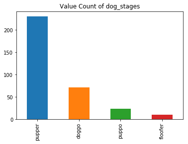

```python
dog_stagesdf['dog_stage'].value_counts().plot(kind='bar');
plt.title('Value Count of dog_stages');
```

```python
The plot revealed that pupper has the highest value count while floofer has the lowest
```

```python
dog_stagesdf['ratings']=dog_stagesdf['rating_numerator']/dog_stagesdf['rating_denominator']
```

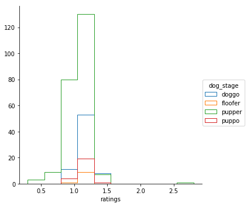

```python
bin_edges=np.arange(0.3, dog_stagesdf['ratings'].max()+1/4, 1/4)
g=sb.FacetGrid(data=dog_stagesdf, hue='dog_stage',size=5)
g.map(plt.hist, 'ratings', bins=bin_edges, histtype='step')
g.add_legend()
```

```python
dog_stagesdf['ratings'].max()
```

```
2.7000000000000002
```

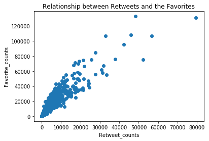

```python
plt.scatter(df.retweet_count, df.favorite_count);
plt.title('Relationship between Retweets and the Favorites');
plt.xlabel('Retweet_counts');
plt.ylabel('Favorite_counts');
```

It appears that there is a linear relationship between the retweet counts and the favorite counts